# Exploring Tunisian Emigration Patterns

Dridi Slim

2024-05-09

# Introduction:

- Tunisia, a North African country with a rich history and diverse cultural heritage, has experienced significant emigration over the past few decades.
- In this project, we aim to study the various opinions on Tunisian emigration.
- The survey: The survey was created using Google Forms and distributed to respondents mainly through Gmail. The data was then collected in an Excel file and subsequently processed using the R programming language.

# Setting up the environment:

## Importing packages:

```r
library(readxl) #used for importing exel data
library(FactoMineR) #used for applying PCA, MCA & classification
library(factoextra) #
library(ggplot2) # visualization
library(dplyr) # data manipulation
library(corrplot) # plotting the corrolation
library(questionr)
library(flextable) # print pretty tables
```

## Importing Data:

```r
data <- read_excel("D://Analyse//PCA//final_data.xlsx")
data <- data.frame(data)
```

# data overview:

```r
paste("In our data, We have",ncol(data),"variable And",nrow(data),"Observation")
```

```
## [1] "In our data, We have 43 variable And 35 Observation"
```

# Descriptive statistics:

## Sexe Pie chart:

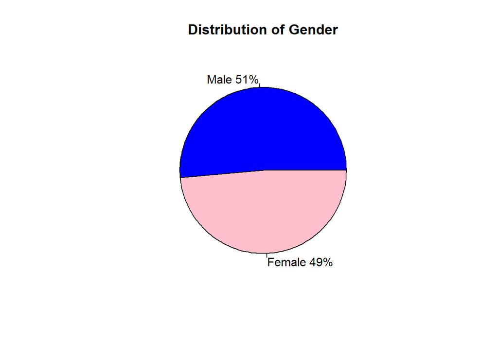

```r
data$sexe<-factor(data$sexe,levels=c("Male","Female"))
freq=table((data$sexe))
perc<- round(freq/sum(freq)*100)
labls1 <- paste(c("Male","Female"),perc)
labls1 <- paste(labls1,"%",sep="")
pie(freq,labels = labls1,col=c("blue", "pink"),main="Distribution of Gender")
```

> The chart effectively visualizes the nearly equal distribution between males and females, highlighting gender eaqual distribution within the dataset.

## Age Pie chart:

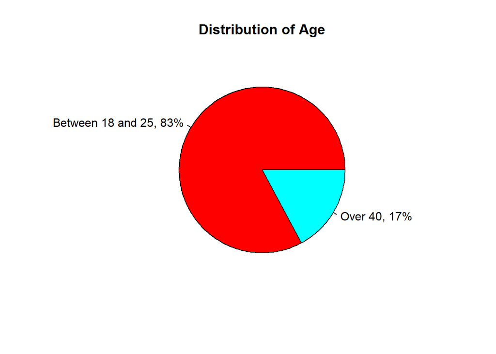

```r
data$sexe<-factor(data$Age,levels=c("Between 18 and 25","Over 40"))
freq=table((data$Age))
perc <- round(freq/sum(freq)*100)
labls1 <- paste(c("Between 18 and 25,","Over 40,"),perc)
labls1 <- paste(labls1,"%",sep="")
pie(freq,labels = labls1, col=rainbow(length(labls1)),main="Distribution of Age")
```

> The chart highlights a notable disparity in age distribution, with a substantial majority of individuals falling within the 18 to 25 age range.

## Education Pie chart:

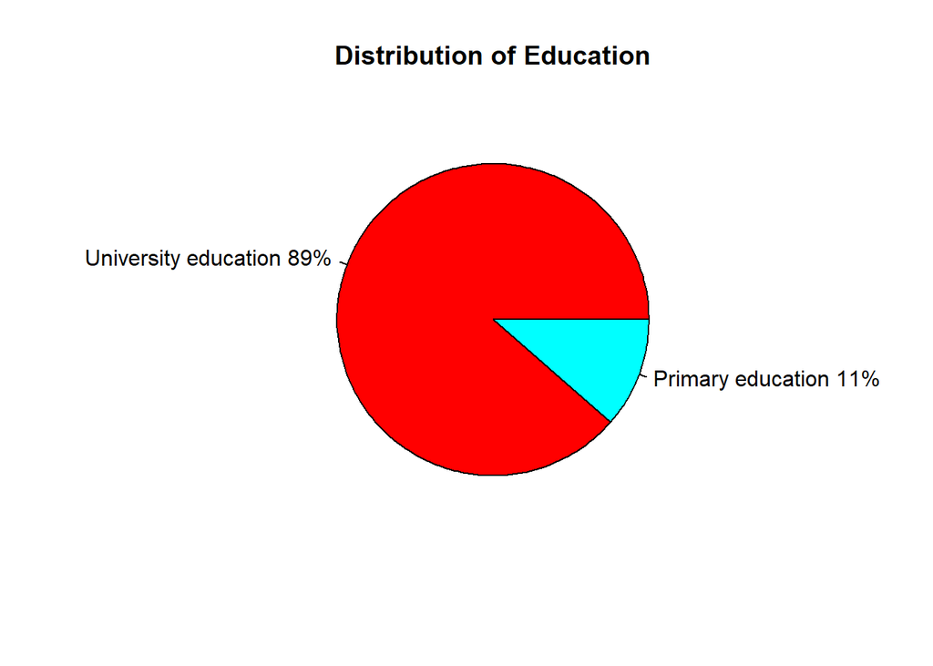

```r
data$education<-factor(data$education,levels=c("University education","Primary education"))
freq=table((data$education))
perc <- round(freq/sum(freq)*100)
labls1 <- paste(c("University education","Primary education"),perc)
labls1 <- paste(labls1,"%",sep="")
pie(freq,labels = labls1, col=rainbow(length(labls1)),main="Distribution of Education")
```

> This char reveals a significant educational trend.

## country of choice Pie chart:

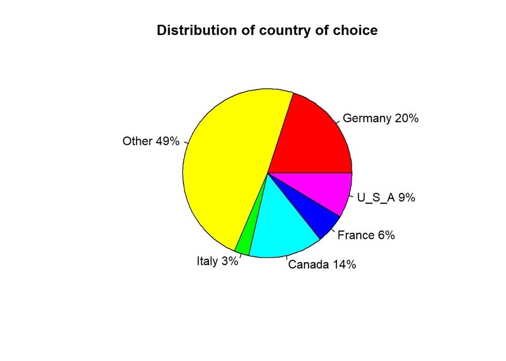

```r
data$Country_of_choice<-factor(data$Country_of_choice,levels=c("Germany","Other","Italy","Canada","France","U_S_A"))
freq=table((data$Country_of_choice))
perc <- round(freq/sum(freq)*100)
labls1 <- paste(c("Germany","Other","Italy","Canada","France","U_S_A"),perc)
labls1 <- paste(labls1,"%",sep="")
pie(freq,labels = labls1, col=rainbow(length(labls1)),main="Distribution of country of choice")
```

# Principal Component Analysis (PCA):

## Perform Principal Component Analysis:

```r
X2=as.matrix(data[,22:31])
res.pca2 <- PCA (X2,graph=F)
res.pca2
```

```
## **Results for the Principal Component Analysis (PCA)**
## The analysis was performed on 35 individuals, described by 10 variables
## *The results are available in the following objects:
##
##    name               description
## 1  "$eig"             "eigenvalues"
## 2  "$var"             "results for the variables"
## 3  "$var$coord"       "coord. for the variables"
## 4  "$var$cor"         "correlations variables - dimensions"
## 5  "$var$cos2"        "cos2 for the variables"
## 6  "$var$contrib"     "contributions of the variables"
## 7  "$ind"             "results for the individuals"
## 8  "$ind$coord"       "coord. for the individuals"
## 9  "$ind$cos2"        "cos2 for the individuals"
## 10 "$ind$contrib"     "contributions of the individuals"
## 11 "$call"            "summary statistics"
## 12 "$call$centre"     "mean of the variables"
## 13 "$call$ecart.type" "standard error of the variables"
## 14 "$call$row.w"      "weights for the individuals"
## 15 "$call$col.w"      "weights for the variables"
```

## Calculating eigenvalues from PCA results:

```r
#get the eignvalue
eig_val2 <- res.pca2$eig

#transform to a better table
eig_val2<-data.frame(eig_val2)
DIM <- paste("Dim.", 1:10, sep = "")
eig_val2 <- cbind(DIM,eig_val2)
ft <- flextable(eig_val2)
ft <- autofit(ft)
theme_zebra(ft)
```

| DIM | eigenvalue | percentage.of.variance | cumulative.percentage.of.variance |
| --- | --- | --- | --- |
| Dim.1 | 4.8725584 | 48.725584 | 48.72558 |
| Dim.2 | 1.5640172 | 15.640172 | 64.36576 |
| Dim.3 | 0.8640884 | 8.640884 | 73.00664 |
| Dim.4 | 0.7713012 | 7.713012 | 80.71965 |
| Dim.5 | 0.7023885 | 7.023885 | 87.74354 |
| Dim.6 | 0.3520669 | 3.520669 | 91.26421 |
| Dim.7 | 0.2852119 | 2.852119 | 94.11633 |
| Dim.8 | 0.2331341 | 2.331341 | 96.44767 |
| Dim.9 | 0.2140466 | 2.140466 | 98.58813 |
| Dim.10 | 0.1411867 | 1.411867 | 100.00000 |

## Extracting variables from PCA results:

```r
var1 <- get_pca_var(res.pca2)
var1
```

```
## Principal Component Analysis Results for variables
##  ===================================================
##   Name       Description
## 1 "$coord"   "Coordinates for the variables"
## 2 "$cor"     "Correlations between variables and dimensions"
## 3 "$cos2"    "Cos2 for the variables"
## 4 "$contrib" "contributions of the variables"
```

## Correlation plot using cos²:

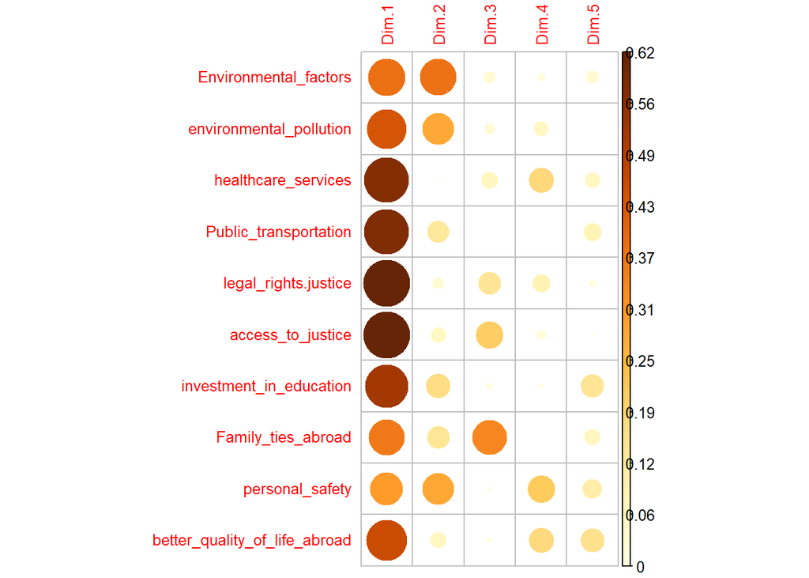

```r
corrplot(var1$cos2,tl.cex = 0.8, is.corr=F)
```

> The higher the cos2, the better the variable is represented. Our variables demonstrate high correlation with the first dimension.

## Coordinates of variables:

```r
s<-res.pca2$var$coord

s<-data.frame(s)
Question <- paste("Q.", 1:10, sep = "")
s <- cbind(Question,s)
ft <- qflextable(s)
ft <- autofit(ft)
theme_zebra(ft)
```

| Question | Dim.1 | Dim.2 | Dim.3 | Dim.4 | Dim.5 |
| --- | --- | --- | --- | --- | --- |
| Q.1 | 0.6230262 | -0.61839615 | 0.192847731 | -0.133179701 | 0.20620532 |
| Q.2 | 0.6665378 | -0.52845977 | -0.177717284 | 0.245623500 | -0.01368835 |
| Q.3 | 0.7550749 | 0.03664609 | 0.271895785 | -0.424221346 | -0.26001239 |
| Q.4 | 0.7593689 | -0.36451374 | -0.003391608 | 0.005584952 | 0.29618434 |
| Q.5 | 0.7858247 | 0.18773369 | -0.381839069 | -0.301493335 | 0.12066604 |
| Q.6 | 0.7855554 | 0.25672899 | -0.457397363 | -0.149838926 | -0.04881122 |
| Q.7 | 0.7229593 | 0.40895478 | 0.111885154 | 0.081595308 | -0.38363534 |
| Q.8 | 0.6056028 | 0.37957597 | 0.583170606 | -0.020432341 | 0.26900539 |
| Q.9 | 0.5521912 | 0.53294066 | -0.074231686 | 0.463941635 | 0.32956141 |
| Q.10 | 0.6814598 | -0.26761735 | 0.090807118 | 0.421392350 | -0.39906813 |

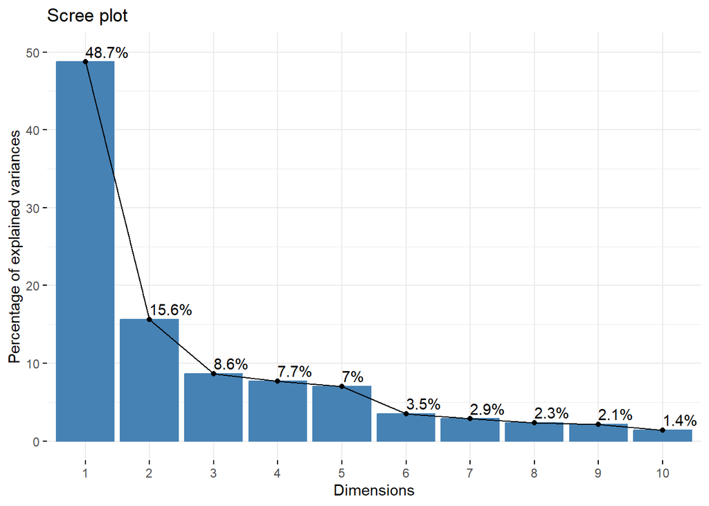

```r
fviz_eig(res.pca2, addlabels = TRUE, ylim = c(0, 50))
```

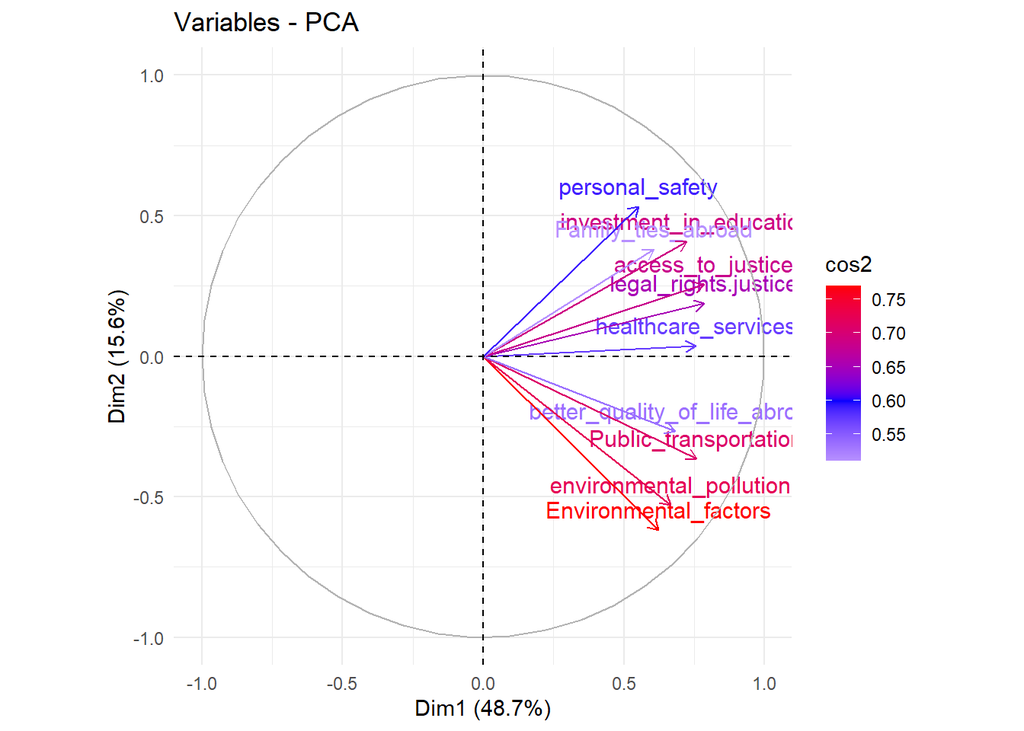

```r
fviz_pca_var(res.pca2, axes=c(1,2), col.var="cos2") +
scale_color_gradient2(low="white", mid="blue",
high="red", midpoint=0.6) +
theme_minimal()
```

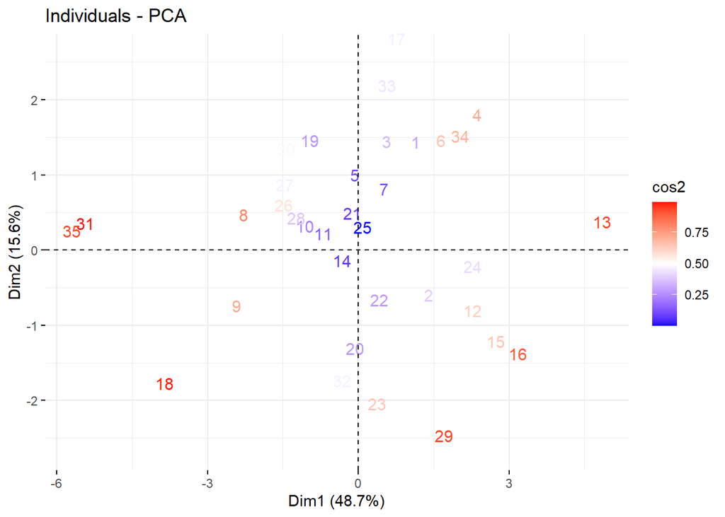

```r
fviz_pca_ind(res.pca2,geom ="text",col.ind="cos2")+
scale_color_gradient2(low="blue", mid="white",
high="red", midpoint=0.5)
```

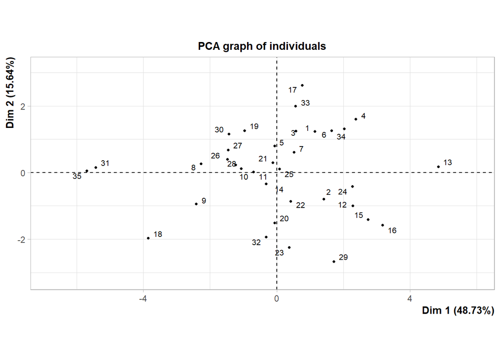

```r
plot.PCA(res.pca2, axes=c(1, 2), choix="ind", cex=0.7)
```

# MCA

```r
res.mca <- MCA (data[,3:8], graph = FALSE)

d<-data.frame(res.mca$eig)
DIM <- paste("Dim.", 1:6, sep = "")
d <- cbind(DIM,d)
ft <- flextable(d)
ft <- autofit(ft)
theme_zebra(ft)
```

| DIM | eigenvalue | percentage.of.variance | cumulative.percentage.of.variance |
| --- | --- | --- | --- |
| Dim.1 | 0.30372968 | 30.372968 | 30.37297 |
| Dim.2 | 0.22918314 | 22.918314 | 53.29128 |
| Dim.3 | 0.15304834 | 15.304834 | 68.59612 |
| Dim.4 | 0.13054340 | 13.054340 | 81.65046 |
| Dim.5 | 0.10782506 | 10.782506 | 92.43296 |
| Dim.6 | 0.07567039 | 7.567039 | 100.00000 |

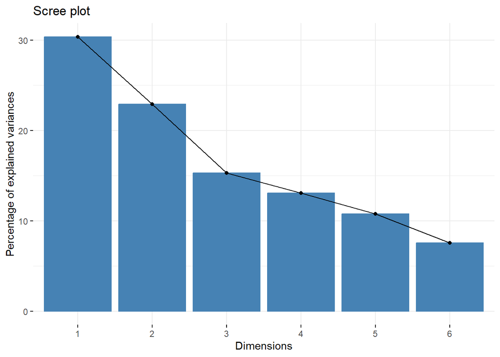

```r
fviz_screeplot(res.mca)
```

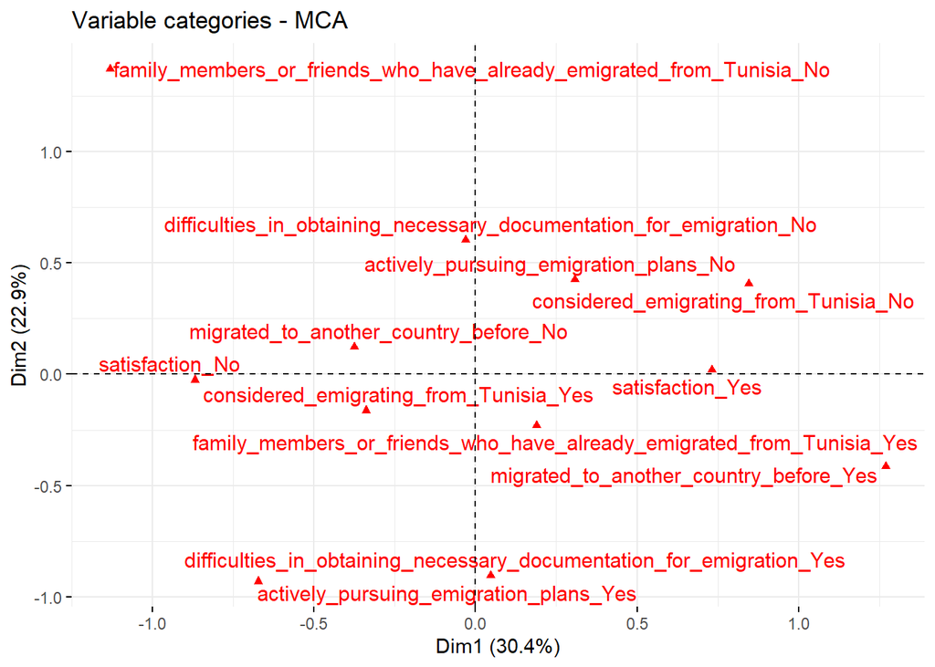

```r
fviz_mca_var(res.mca,repel = TRUE,ggtheme = theme_minimal ())
```

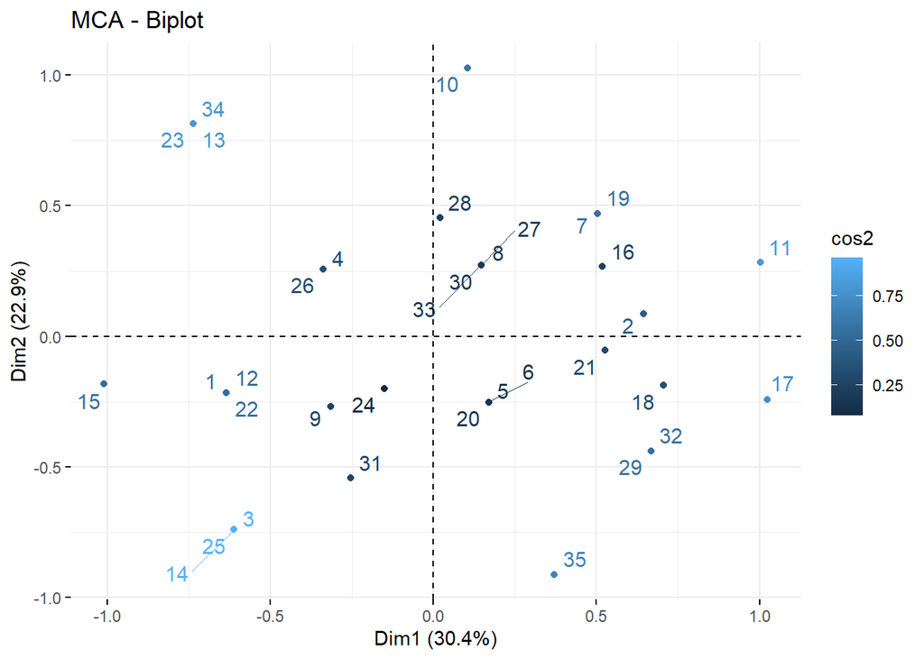

```r
fviz_mca_biplot(res.mca,
col.ind="cos2",
invisible ="var",repel = TRUE,
ggtheme = theme_minimal ())
```

# Classification:

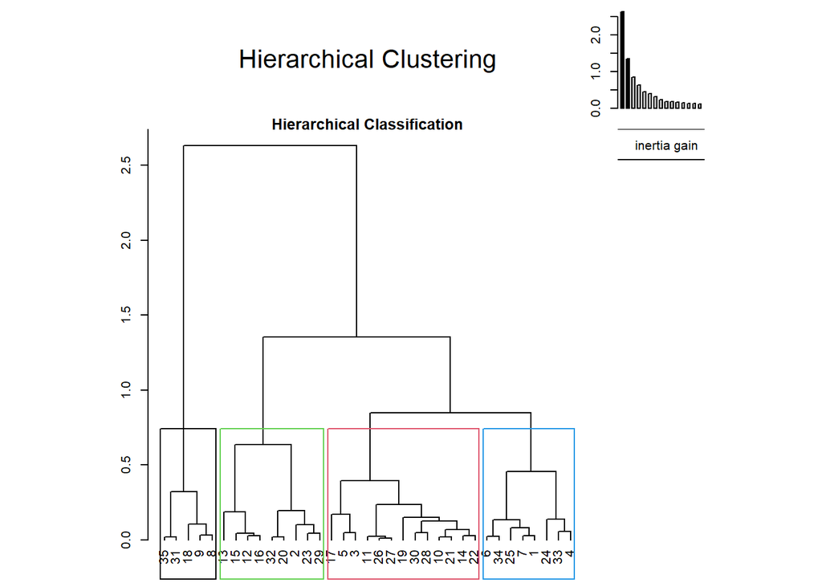

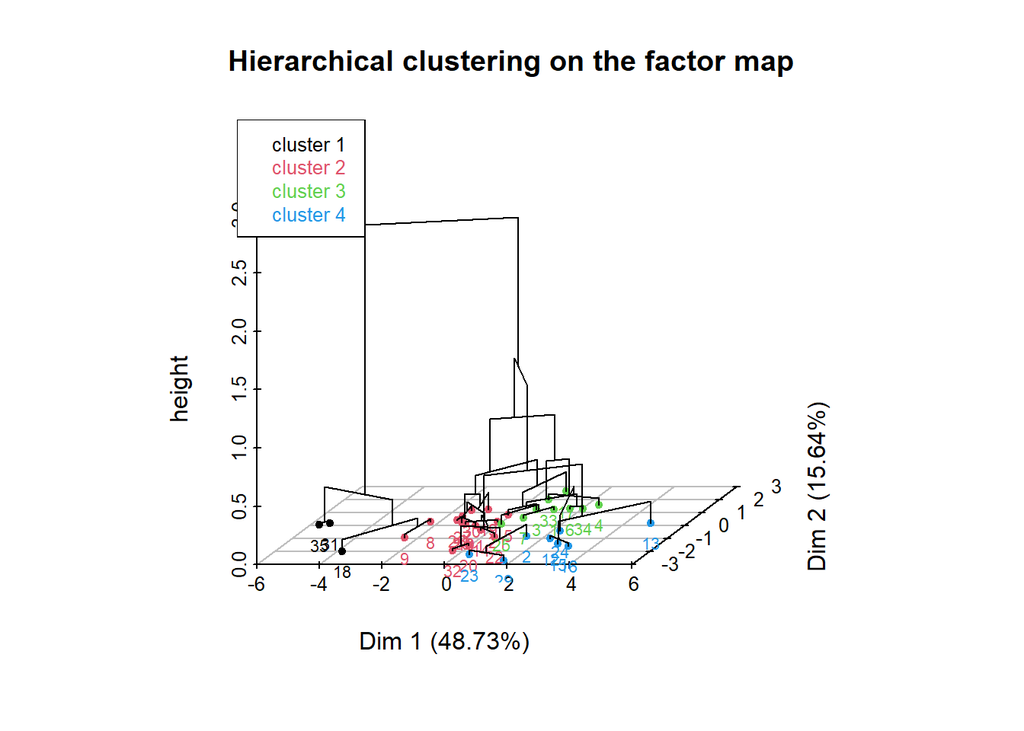

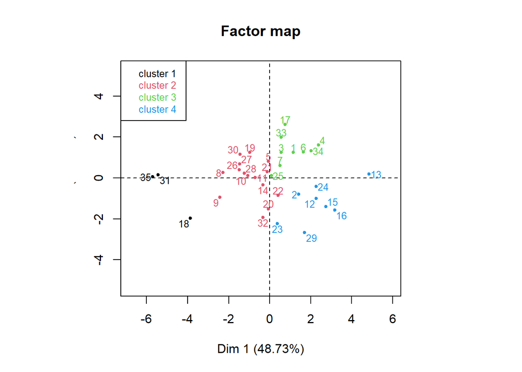

```
## **Results for the Hierarchical Clustering on Principal Components**
##    name
## 1  "$data.clust"
## 2  "$desc.var"
## 3  "$desc.var$quanti.var"
## 4  "$desc.var$quanti"
## 5  "$desc.axes"
## 6  "$desc.axes$quanti.var"
## 7  "$desc.axes$quanti"
## 8  "$desc.ind"
## 9  "$desc.ind$para"
## 10 "$desc.ind$dist"
## 11 "$call"
## 12 "$call$t"
##    description
## 1  "dataset with the cluster of the individuals"
## 2  "description of the clusters by the variables"
## 3  "description of the cluster var. by the continuous var."
## 4  "description of the clusters by the continuous var."
## 5  "description of the clusters by the dimensions"
## 6  "description of the cluster var. by the axes"
## 7  "description of the clusters by the axes"
## 8  "description of the clusters by the individuals"
## 9  "parangons of each clusters"
## 10 "specific individuals"
## 11 "summary statistics"
## 12 "description of the tree"
```

```r
res.pca <- PCA(X2, ncp = 4, graph = FALSE)
res.hcpc <- HCPC(res.pca,nb.clust = 4, graph = FALSE)
HCPC (res.pca2, nb.clust = 4, graph = TRUE)
```

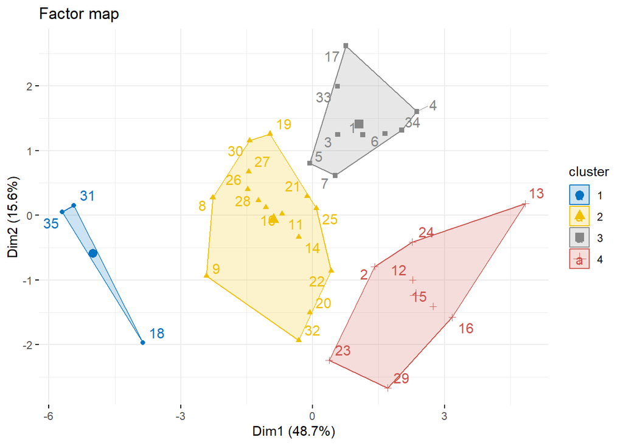

```r
fviz_cluster(res.hcpc,
repel = TRUE,
show.clust.cent = TRUE,
palette = "jco",
ggtheme = theme_minimal(),
main = "Factor map"
)
```